# Индивидуальный проект - Этап 1

Основы информационной безопасности

Чистов Д. М.

Российский университет дружбы народов, Москва, Россия

Объединённый институт ядерных исследований, Дубна, Россия

07 марта 2025

# Цель работы

Установка дистрибутива Kali Linux на виртуальную машину

## Задание

1. Установка Kali Linux

# Выполнение лабораторной работы

Перейдём к созданию новой виртуальной машины - Задаю имя и выбираю образ, который я зарнее скачал с официального сайта Kali Linux.

[figure not shown]

Первоначальная настройка виртуальной машины

## Выполнение лабораторной работы

Выделяю 4гб оперативной памяти и 3 ЦП.

[figure not shown]

Задание Оперативной памяти и цп

## Выполнение лабораторной работы

Выделяю 40 гб места для моей ОС.

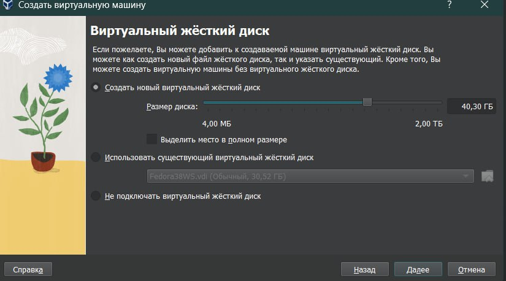

Создание виртуального жёсткого диска

## Выполнение лабораторной работы

Итоговые характеристики моей виртуальной машины.

[figure not shown]

Характеристики виртуальной машины

## Выполнение лабораторной работы

Перейдём к установке ОС. Выбираю графический способ установки.

[figure not shown]

Графическая установка ОС

## Выполнение лабораторной работы

Выбираю язык установщика, который также будет использоваться в моей ОС, как основной.

[figure not shown]

Русский язык ОС

## Выполнение лабораторной работы

Выбираю язык для клавиатуры.

[figure not shown]

Русская раскладка для ввода

## Выполнение лабораторной работы

Задаю имя “компьютера” согласно регламенту.

[figure not shown]

Имя “компьютера”

## Выполнение лабораторной работы

Задаю имя домена.

[figure not shown]

Имя домена

## Выполнение лабораторной работы

Задаю имя пользователя согласно регламенту.

[figure not shown]

Имя пользователя

## Выполнение лабораторной работы

Задаю имя учётной записи.

[figure not shown]

Имя учётной записи

## Выполнение лабораторной работы

Задаю пароль для учётной записи.

[figure not shown]

Пароль для учётной записи

## Выполнение лабораторной работы

Задаю часовой - Москва.

[figure not shown]

Часовой пояс

## Выполнение лабораторной работы

Выбираю метод разметки диска.

[figure not shown]

Метод разметки

## Выполнение лабораторной работы

Выбираю жёсткий диск.

[figure not shown]

Жёсткий диск

## Выполнение лабораторной работы

Подтверждаю схему разметки.

[figure not shown]

Схема разметки

## Выполнение лабораторной работы

Завершение процесса разметки дисков.

[figure not shown]

Завершение разметки дисков

## Выполнение лабораторной работы

Началась устанвока базовой системы Kali Linux.

[figure not shown]

Установка базовой системы

## Выполнение лабораторной работы

Выбор программного обеспечения - я решил выбрать xfce, т.к. узнал, что это способствует быстродействую ОС, по сравнению с аналогами.

[figure not shown]

Выбор ПО

## Выполнение лабораторной работы

Установка системного загрузчика.

[figure not shown]

Системный загрузчик GRUB

## Выполнение лабораторной работы

Система успешно установлена.

[figure not shown]

Kali Linux готов к использованию

# Выводы

При выполнении данной лабораторной работы - я вспомнил, как устанавливать операционный системы, приступил к знакомству с Kali Linux.

# Список литературы

[Индивидуальный проект](https://esystem.rudn.ru/mod/page/view.php?id=1220137#citeproc_bib_item_1)

[Сайт Kali Linux](https://www.kali.org/)